# Optimal Treatment Analysis

## Outcome Variable

**Outcome Variable:** ever_wasted

## Predictor Variables

**Intervention Variable:** mbmi

**Adjustment Set:**

- arm
- W_mage
- meducyrs
- feducyrs
- single
- brthmon
- W_parity
- delta_W_mage
- delta_meducyrs
- delta_feducyrs
- delta_single
- delta_brthmon
- delta_W_parity

## Stratifying Variables

The analysis was stratified on these variable(s):

- agecat
- studyid
- country

## Data Summary

| agecat | studyid | country | mbmi | ever_wasted | n_cell | n |
| --- | --- | --- | --- | --- | --- | --- |
| 0-24 months | ki0047075b-MAL-ED | BANGLADESH | Normal weight | 0 | 154 | 254 |
| 0-24 months | ki0047075b-MAL-ED | BANGLADESH | Normal weight | 1 | 68 | 254 |
| 0-24 months | ki0047075b-MAL-ED | BANGLADESH | Underweight | 0 | 15 | 254 |
| 0-24 months | ki0047075b-MAL-ED | BANGLADESH | Underweight | 1 | 17 | 254 |
| 0-24 months | ki0047075b-MAL-ED | BRAZIL | Normal weight | 0 | 194 | 221 |
| 0-24 months | ki0047075b-MAL-ED | BRAZIL | Normal weight | 1 | 17 | 221 |
| 0-24 months | ki0047075b-MAL-ED | BRAZIL | Underweight | 0 | 8 | 221 |
| 0-24 months | ki0047075b-MAL-ED | BRAZIL | Underweight | 1 | 2 | 221 |
| 0-24 months | ki0047075b-MAL-ED | INDIA | Normal weight | 0 | 107 | 242 |
| 0-24 months | ki0047075b-MAL-ED | INDIA | Normal weight | 1 | 86 | 242 |
| 0-24 months | ki0047075b-MAL-ED | INDIA | Underweight | 0 | 20 | 242 |
| 0-24 months | ki0047075b-MAL-ED | INDIA | Underweight | 1 | 29 | 242 |
| 0-24 months | ki0047075b-MAL-ED | NEPAL | Normal weight | 0 | 169 | 238 |
| 0-24 months | ki0047075b-MAL-ED | NEPAL | Normal weight | 1 | 69 | 238 |
| 0-24 months | ki0047075b-MAL-ED | NEPAL | Underweight | 0 | 0 | 238 |
| 0-24 months | ki0047075b-MAL-ED | NEPAL | Underweight | 1 | 0 | 238 |
| 0-24 months | ki0047075b-MAL-ED | PERU | Normal weight | 0 | 261 | 290 |
| 0-24 months | ki0047075b-MAL-ED | PERU | Normal weight | 1 | 24 | 290 |
| 0-24 months | ki0047075b-MAL-ED | PERU | Underweight | 0 | 3 | 290 |
| 0-24 months | ki0047075b-MAL-ED | PERU | Underweight | 1 | 2 | 290 |
| 0-24 months | ki0047075b-MAL-ED | SOUTH AFRICA | Normal weight | 0 | 207 | 270 |
| 0-24 months | ki0047075b-MAL-ED | SOUTH AFRICA | Normal weight | 1 | 55 | 270 |
| 0-24 months | ki0047075b-MAL-ED | SOUTH AFRICA | Underweight | 0 | 8 | 270 |
| 0-24 months | ki0047075b-MAL-ED | SOUTH AFRICA | Underweight | 1 | 0 | 270 |
| 0-24 months | ki0047075b-MAL-ED | TANZANIA, UNITED REPUBLIC OF | Normal weight | 0 | 214 | 256 |
| 0-24 months | ki0047075b-MAL-ED | TANZANIA, UNITED REPUBLIC OF | Normal weight | 1 | 28 | 256 |
| 0-24 months | ki0047075b-MAL-ED | TANZANIA, UNITED REPUBLIC OF | Underweight | 0 | 10 | 256 |
| 0-24 months | ki0047075b-MAL-ED | TANZANIA, UNITED REPUBLIC OF | Underweight | 1 | 4 | 256 |
| 0-24 months | ki1000304b-SAS-CompFeed | INDIA | Normal weight | 0 | 210 | 410 |
| 0-24 months | ki1000304b-SAS-CompFeed | INDIA | Normal weight | 1 | 91 | 410 |

[output cut: 158 more lines]

The following strata were considered:

- agecat: 0-24 months, studyid: ki0047075b-MAL-ED, country: BANGLADESH
- agecat: 0-24 months, studyid: ki0047075b-MAL-ED, country: BRAZIL
- agecat: 0-24 months, studyid: ki0047075b-MAL-ED, country: INDIA
- agecat: 0-24 months, studyid: ki0047075b-MAL-ED, country: NEPAL
- agecat: 0-24 months, studyid: ki0047075b-MAL-ED, country: PERU
- agecat: 0-24 months, studyid: ki0047075b-MAL-ED, country: SOUTH AFRICA
- agecat: 0-24 months, studyid: ki0047075b-MAL-ED, country: TANZANIA, UNITED REPUBLIC OF
- agecat: 0-24 months, studyid: ki1000304b-SAS-CompFeed, country: INDIA
- agecat: 0-24 months, studyid: ki1017093-NIH-Birth, country: BANGLADESH
- agecat: 0-24 months, studyid: ki1017093b-PROVIDE, country: BANGLADESH
- agecat: 0-24 months, studyid: ki1017093c-NIH-Crypto, country: BANGLADESH
- agecat: 0-24 months, studyid: ki1066203-TanzaniaChild2, country: TANZANIA, UNITED REPUBLIC OF
- agecat: 0-24 months, studyid: ki1112895-iLiNS-Zinc, country: BURKINA FASO
- agecat: 0-24 months, studyid: ki1119695-PROBIT, country: BELARUS
- agecat: 0-24 months, studyid: ki1126311-ZVITAMBO, country: ZIMBABWE
- agecat: 0-24 months, studyid: ki1148112-LCNI-5, country: MALAWI
- agecat: 0-6 months, studyid: ki0047075b-MAL-ED, country: BANGLADESH
- agecat: 0-6 months, studyid: ki0047075b-MAL-ED, country: BRAZIL
- agecat: 0-6 months, studyid: ki0047075b-MAL-ED, country: INDIA
- agecat: 0-6 months, studyid: ki0047075b-MAL-ED, country: NEPAL
- agecat: 0-6 months, studyid: ki0047075b-MAL-ED, country: PERU
- agecat: 0-6 months, studyid: ki0047075b-MAL-ED, country: SOUTH AFRICA
- agecat: 0-6 months, studyid: ki0047075b-MAL-ED, country: TANZANIA, UNITED REPUBLIC OF
- agecat: 0-6 months, studyid: ki1000304b-SAS-CompFeed, country: INDIA
- agecat: 0-6 months, studyid: ki1017093-NIH-Birth, country: BANGLADESH
- agecat: 0-6 months, studyid: ki1017093b-PROVIDE, country: BANGLADESH
- agecat: 0-6 months, studyid: ki1017093c-NIH-Crypto, country: BANGLADESH
- agecat: 0-6 months, studyid: ki1066203-TanzaniaChild2, country: TANZANIA, UNITED REPUBLIC OF
- agecat: 0-6 months, studyid: ki1119695-PROBIT, country: BELARUS
- agecat: 0-6 months, studyid: ki1126311-ZVITAMBO, country: ZIMBABWE
- agecat: 0-6 months, studyid: ki1148112-LCNI-5, country: MALAWI
- agecat: 6-24 months, studyid: ki0047075b-MAL-ED, country: BANGLADESH
- agecat: 6-24 months, studyid: ki0047075b-MAL-ED, country: BRAZIL
- agecat: 6-24 months, studyid: ki0047075b-MAL-ED, country: INDIA
- agecat: 6-24 months, studyid: ki0047075b-MAL-ED, country: NEPAL
- agecat: 6-24 months, studyid: ki0047075b-MAL-ED, country: PERU
- agecat: 6-24 months, studyid: ki0047075b-MAL-ED, country: SOUTH AFRICA
- agecat: 6-24 months, studyid: ki0047075b-MAL-ED, country: TANZANIA, UNITED REPUBLIC OF
- agecat: 6-24 months, studyid: ki1000304b-SAS-CompFeed, country: INDIA
- agecat: 6-24 months, studyid: ki1017093-NIH-Birth, country: BANGLADESH
- agecat: 6-24 months, studyid: ki1017093b-PROVIDE, country: BANGLADESH
- agecat: 6-24 months, studyid: ki1017093c-NIH-Crypto, country: BANGLADESH
- agecat: 6-24 months, studyid: ki1066203-TanzaniaChild2, country: TANZANIA, UNITED REPUBLIC OF
- agecat: 6-24 months, studyid: ki1112895-iLiNS-Zinc, country: BURKINA FASO
- agecat: 6-24 months, studyid: ki1119695-PROBIT, country: BELARUS
- agecat: 6-24 months, studyid: ki1126311-ZVITAMBO, country: ZIMBABWE
- agecat: 6-24 months, studyid: ki1148112-LCNI-5, country: MALAWI

### Dropped Strata

Some strata were dropped due to rare outcomes:

- agecat: 0-24 months, studyid: ki0047075b-MAL-ED, country: BRAZIL
- agecat: 0-24 months, studyid: ki0047075b-MAL-ED, country: NEPAL
- agecat: 0-24 months, studyid: ki0047075b-MAL-ED, country: PERU
- agecat: 0-24 months, studyid: ki0047075b-MAL-ED, country: SOUTH AFRICA
- agecat: 0-24 months, studyid: ki0047075b-MAL-ED, country: TANZANIA, UNITED REPUBLIC OF
- agecat: 0-6 months, studyid: ki0047075b-MAL-ED, country: BRAZIL
- agecat: 0-6 months, studyid: ki0047075b-MAL-ED, country: NEPAL
- agecat: 0-6 months, studyid: ki0047075b-MAL-ED, country: PERU
- agecat: 0-6 months, studyid: ki0047075b-MAL-ED, country: SOUTH AFRICA
- agecat: 0-6 months, studyid: ki0047075b-MAL-ED, country: TANZANIA, UNITED REPUBLIC OF
- agecat: 0-6 months, studyid: ki1148112-LCNI-5, country: MALAWI
- agecat: 6-24 months, studyid: ki0047075b-MAL-ED, country: BRAZIL
- agecat: 6-24 months, studyid: ki0047075b-MAL-ED, country: NEPAL
- agecat: 6-24 months, studyid: ki0047075b-MAL-ED, country: PERU
- agecat: 6-24 months, studyid: ki0047075b-MAL-ED, country: SOUTH AFRICA
- agecat: 6-24 months, studyid: ki0047075b-MAL-ED, country: TANZANIA, UNITED REPUBLIC OF
- agecat: 6-24 months, studyid: ki1119695-PROBIT, country: BELARUS

## Methods Detail

We’re interested in the causal parameters $E[Y_a]$ for all values of $a \in \mathcal{A}$. These parameters represent the mean outcome if, possibly contrary to fact, we intervened to set all units to have $A=a$. Under the randomization and positivity assumptions, these are identified by the statistical parameters $\psi_a=E_W[E_{Y|A,W}(Y|A=a,W)]$. In addition, we’re interested in the mean of $Y$, $E[Y]$ under no intervention (the observed mean). We will estimate these parameters by using SuperLearner to fit the relevant likelihood factors – $E_{Y|A,W}(Y|A=a,W)$ and $p(A=a|W)$, and then updating our likelihood fit using a joint TMLE.

For unadjusted analyses ($W=\{\}$), initial likelihoods were estimated using Lrnr_glm to estimate the simple $E(Y|A)$ and Lrnr_mean to estimate $p(A)$. For adjusted analyses, a small library containing Lrnr_glmnet, Lrnr_xgboost, and Lrnr_mean was used.

Having estimated these parameters, we will then use the delta method to estimate relative risks and attributable risks relative to a prespecified baseline level of $A$.

# Results Detail

## Results Plots

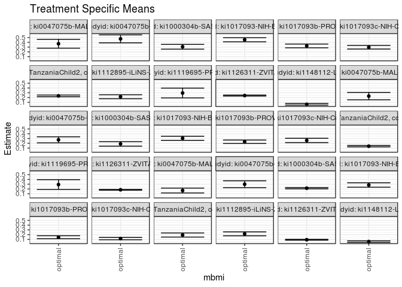

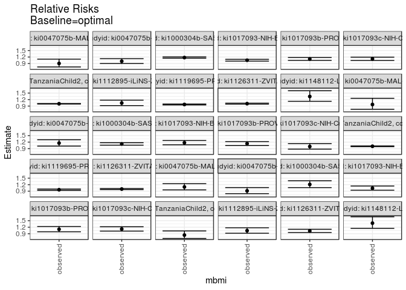

## Results Table

### Parameter: TSM

| agecat | studyid | country | intervention_level | baseline_level | estimate | ci_lower | ci_upper |
| --- | --- | --- | --- | --- | --- | --- | --- |
| 0-24 months | ki0047075b-MAL-ED | BANGLADESH | optimal | NA | 0.3699629 | 0.2770692 | 0.4628566 |
| 0-24 months | ki0047075b-MAL-ED | INDIA | optimal | NA | 0.4720854 | 0.3888601 | 0.5553107 |
| 0-24 months | ki1000304b-SAS-CompFeed | INDIA | optimal | NA | 0.3071321 | 0.2573813 | 0.3568830 |
| 0-24 months | ki1017093-NIH-Birth | BANGLADESH | optimal | NA | 0.4540975 | 0.4111579 | 0.4970371 |
| 0-24 months | ki1017093b-PROVIDE | BANGLADESH | optimal | NA | 0.3246476 | 0.2850222 | 0.3642731 |
| 0-24 months | ki1017093c-NIH-Crypto | BANGLADESH | optimal | NA | 0.2970361 | 0.2593964 | 0.3346757 |
| 0-24 months | ki1066203-TanzaniaChild2 | TANZANIA, UNITED REPUBLIC OF | optimal | NA | 0.2354495 | 0.2179584 | 0.2529406 |
| 0-24 months | ki1112895-iLiNS-Zinc | BURKINA FASO | optimal | NA | 0.2170346 | 0.1756712 | 0.2583981 |
| 0-24 months | ki1119695-PROBIT | BELARUS | optimal | NA | 0.2952030 | 0.1927731 | 0.3976330 |
| 0-24 months | ki1126311-ZVITAMBO | ZIMBABWE | optimal | NA | 0.2420974 | 0.2319205 | 0.2522742 |
| 0-24 months | ki1148112-LCNI-5 | MALAWI | optimal | NA | 0.0587307 | 0.0412586 | 0.0762028 |
| 0-6 months | ki0047075b-MAL-ED | BANGLADESH | optimal | NA | 0.2304570 | 0.1534439 | 0.3074701 |
| 0-6 months | ki0047075b-MAL-ED | INDIA | optimal | NA | 0.2718221 | 0.2089207 | 0.3347236 |
| 0-6 months | ki1000304b-SAS-CompFeed | INDIA | optimal | NA | 0.1865131 | 0.1390776 | 0.2339487 |
| 0-6 months | ki1017093-NIH-Birth | BANGLADESH | optimal | NA | 0.3043509 | 0.2616256 | 0.3470763 |
| 0-6 months | ki1017093b-PROVIDE | BANGLADESH | optimal | NA | 0.2325242 | 0.1968845 | 0.2681640 |
| 0-6 months | ki1017093c-NIH-Crypto | BANGLADESH | optimal | NA | 0.2589926 | 0.2135120 | 0.3044733 |
| 0-6 months | ki1066203-TanzaniaChild2 | TANZANIA, UNITED REPUBLIC OF | optimal | NA | 0.1391387 | 0.1248854 | 0.1533919 |
| 0-6 months | ki1119695-PROBIT | BELARUS | optimal | NA | 0.2921286 | 0.1900549 | 0.3942023 |
| 0-6 months | ki1126311-ZVITAMBO | ZIMBABWE | optimal | NA | 0.1827818 | 0.1738706 | 0.1916929 |
| 6-24 months | ki0047075b-MAL-ED | BANGLADESH | optimal | NA | 0.1674863 | 0.1167051 | 0.2182675 |
| 6-24 months | ki0047075b-MAL-ED | INDIA | optimal | NA | 0.2991940 | 0.2277227 | 0.3706653 |
| 6-24 months | ki1000304b-SAS-CompFeed | INDIA | optimal | NA | 0.2159893 | 0.2023678 | 0.2296108 |
| 6-24 months | ki1017093-NIH-Birth | BANGLADESH | optimal | NA | 0.2830560 | 0.2367133 | 0.3293988 |
| 6-24 months | ki1017093b-PROVIDE | BANGLADESH | optimal | NA | 0.1458272 | 0.1145224 | 0.1771320 |
| 6-24 months | ki1017093c-NIH-Crypto | BANGLADESH | optimal | NA | 0.1176899 | 0.0929543 | 0.1424255 |
| 6-24 months | ki1066203-TanzaniaChild2 | TANZANIA, UNITED REPUBLIC OF | optimal | NA | 0.1925165 | 0.1495259 | 0.2355070 |
| 6-24 months | ki1112895-iLiNS-Zinc | BURKINA FASO | optimal | NA | 0.2170346 | 0.1756712 | 0.2583981 |
| 6-24 months | ki1126311-ZVITAMBO | ZIMBABWE | optimal | NA | 0.0938161 | 0.0846851 | 0.1029471 |
| 6-24 months | ki1148112-LCNI-5 | MALAWI | optimal | NA | 0.0551070 | 0.0380601 | 0.0721539 |

### Parameter: E(Y)

| agecat | studyid | country | intervention_level | baseline_level | estimate | ci_lower | ci_upper |
| --- | --- | --- | --- | --- | --- | --- | --- |
| 0-24 months | ki0047075b-MAL-ED | BANGLADESH | observed | NA | 0.3346457 | 0.2765014 | 0.3927899 |
| 0-24 months | ki0047075b-MAL-ED | INDIA | observed | NA | 0.4752066 | 0.4121581 | 0.5382551 |
| 0-24 months | ki1000304b-SAS-CompFeed | INDIA | observed | NA | 0.3609756 | 0.2943508 | 0.4276005 |
| 0-24 months | ki1017093-NIH-Birth | BANGLADESH | observed | NA | 0.4775641 | 0.4383415 | 0.5167867 |
| 0-24 months | ki1017093b-PROVIDE | BANGLADESH | observed | NA | 0.3602392 | 0.3238339 | 0.3966444 |
| 0-24 months | ki1017093c-NIH-Crypto | BANGLADESH | observed | NA | 0.3311258 | 0.2975342 | 0.3647175 |
| 0-24 months | ki1066203-TanzaniaChild2 | TANZANIA, UNITED REPUBLIC OF | observed | NA | 0.2371002 | 0.2198828 | 0.2543177 |
| 0-24 months | ki1112895-iLiNS-Zinc | BURKINA FASO | observed | NA | 0.2259307 | 0.1907517 | 0.2611097 |
| 0-24 months | ki1119695-PROBIT | BELARUS | observed | NA | 0.2875710 | 0.1859343 | 0.3892076 |
| 0-24 months | ki1126311-ZVITAMBO | ZIMBABWE | observed | NA | 0.2450750 | 0.2365573 | 0.2535928 |
| 0-24 months | ki1148112-LCNI-5 | MALAWI | observed | NA | 0.0788530 | 0.0605839 | 0.0971222 |
| 0-6 months | ki0047075b-MAL-ED | BANGLADESH | observed | NA | 0.2244094 | 0.1730022 | 0.2758167 |
| 0-6 months | ki0047075b-MAL-ED | INDIA | observed | NA | 0.3140496 | 0.2554513 | 0.3726479 |
| 0-6 months | ki1000304b-SAS-CompFeed | INDIA | observed | NA | 0.2078240 | 0.1493922 | 0.2662557 |
| 0-6 months | ki1017093-NIH-Birth | BANGLADESH | observed | NA | 0.3569132 | 0.3192325 | 0.3945938 |
| 0-6 months | ki1017093b-PROVIDE | BANGLADESH | observed | NA | 0.2630792 | 0.2296894 | 0.2964690 |
| 0-6 months | ki1017093c-NIH-Crypto | BANGLADESH | observed | NA | 0.2582781 | 0.2270370 | 0.2895193 |
| 0-6 months | ki1066203-TanzaniaChild2 | TANZANIA, UNITED REPUBLIC OF | observed | NA | 0.1402985 | 0.1262390 | 0.1543580 |
| 0-6 months | ki1119695-PROBIT | BELARUS | observed | NA | 0.2823424 | 0.1800585 | 0.3846263 |
| 0-6 months | ki1126311-ZVITAMBO | ZIMBABWE | observed | NA | 0.1824982 | 0.1748345 | 0.1901620 |
| 6-24 months | ki0047075b-MAL-ED | BANGLADESH | observed | NA | 0.1833333 | 0.1342773 | 0.2323893 |
| 6-24 months | ki0047075b-MAL-ED | INDIA | observed | NA | 0.2735043 | 0.2162683 | 0.3307402 |
| 6-24 months | ki1000304b-SAS-CompFeed | INDIA | observed | NA | 0.2617801 | 0.2144185 | 0.3091417 |
| 6-24 months | ki1017093-NIH-Birth | BANGLADESH | observed | NA | 0.2939002 | 0.2554778 | 0.3323226 |
| 6-24 months | ki1017093b-PROVIDE | BANGLADESH | observed | NA | 0.1612378 | 0.1321259 | 0.1903497 |
| 6-24 months | ki1017093c-NIH-Crypto | BANGLADESH | observed | NA | 0.1315068 | 0.1069744 | 0.1560393 |
| 6-24 months | ki1066203-TanzaniaChild2 | TANZANIA, UNITED REPUBLIC OF | observed | NA | 0.1612576 | 0.1450216 | 0.1774936 |
| 6-24 months | ki1112895-iLiNS-Zinc | BURKINA FASO | observed | NA | 0.2259307 | 0.1907517 | 0.2611097 |
| 6-24 months | ki1126311-ZVITAMBO | ZIMBABWE | observed | NA | 0.0965066 | 0.0902505 | 0.1027627 |
| 6-24 months | ki1148112-LCNI-5 | MALAWI | observed | NA | 0.0765492 | 0.0583736 | 0.0947248 |

### Parameter: RR

| agecat | studyid | country | intervention_level | baseline_level | estimate | ci_lower | ci_upper |
| --- | --- | --- | --- | --- | --- | --- | --- |
| 0-24 months | ki0047075b-MAL-ED | BANGLADESH | observed | optimal | 0.9045385 | 0.7424279 | 1.1020463 |
| 0-24 months | ki0047075b-MAL-ED | INDIA | observed | optimal | 1.0066116 | 0.9007039 | 1.1249721 |
| 0-24 months | ki1000304b-SAS-CompFeed | INDIA | observed | optimal | 1.1753105 | 1.1457230 | 1.2056620 |
| 0-24 months | ki1017093-NIH-Birth | BANGLADESH | observed | optimal | 1.0516775 | 1.0107791 | 1.0942307 |
| 0-24 months | ki1017093b-PROVIDE | BANGLADESH | observed | optimal | 1.1096313 | 1.0451107 | 1.1781352 |
| 0-24 months | ki1017093c-NIH-Crypto | BANGLADESH | observed | optimal | 1.1147663 | 1.0405803 | 1.1942413 |
| 0-24 months | ki1066203-TanzaniaChild2 | TANZANIA, UNITED REPUBLIC OF | observed | optimal | 1.0070110 | 0.9961916 | 1.0179479 |
| 0-24 months | ki1112895-iLiNS-Zinc | BURKINA FASO | observed | optimal | 1.0409890 | 0.9232653 | 1.1737235 |
| 0-24 months | ki1119695-PROBIT | BELARUS | observed | optimal | 0.9741463 | 0.9534988 | 0.9952410 |
| 0-24 months | ki1126311-ZVITAMBO | ZIMBABWE | observed | optimal | 1.0122995 | 0.9895072 | 1.0356167 |
| 0-24 months | ki1148112-LCNI-5 | MALAWI | observed | optimal | 1.3426206 | 1.1212800 | 1.6076538 |
| 0-6 months | ki0047075b-MAL-ED | BANGLADESH | observed | optimal | 0.9737584 | 0.7525057 | 1.2600642 |
| 0-6 months | ki0047075b-MAL-ED | INDIA | observed | optimal | 1.1553496 | 1.0193478 | 1.3094967 |
| 0-6 months | ki1000304b-SAS-CompFeed | INDIA | observed | optimal | 1.1142592 | 1.0594217 | 1.1719352 |
| 0-6 months | ki1017093-NIH-Birth | BANGLADESH | observed | optimal | 1.1727028 | 1.0771845 | 1.2766912 |
| 0-6 months | ki1017093b-PROVIDE | BANGLADESH | observed | optimal | 1.1314056 | 1.0471763 | 1.2224099 |
| 0-6 months | ki1017093c-NIH-Crypto | BANGLADESH | observed | optimal | 0.9972413 | 0.8779543 | 1.1327357 |
| 0-6 months | ki1066203-TanzaniaChild2 | TANZANIA, UNITED REPUBLIC OF | observed | optimal | 1.0083359 | 0.9927503 | 1.0241662 |
| 0-6 months | ki1119695-PROBIT | BELARUS | observed | optimal | 0.9665003 | 0.9362258 | 0.9977537 |
| 0-6 months | ki1126311-ZVITAMBO | ZIMBABWE | observed | optimal | 0.9984486 | 0.9742605 | 1.0232372 |
| 6-24 months | ki0047075b-MAL-ED | BANGLADESH | observed | optimal | 1.0946167 | 0.9589806 | 1.2494370 |
| 6-24 months | ki0047075b-MAL-ED | INDIA | observed | optimal | 0.9141368 | 0.7847840 | 1.0648103 |
| 6-24 months | ki1000304b-SAS-CompFeed | INDIA | observed | optimal | 1.2120051 | 1.0639083 | 1.3807170 |
| 6-24 months | ki1017093-NIH-Birth | BANGLADESH | observed | optimal | 1.0383109 | 0.9464642 | 1.1390706 |
| 6-24 months | ki1017093b-PROVIDE | BANGLADESH | observed | optimal | 1.1056769 | 0.9906478 | 1.2340627 |
| 6-24 months | ki1017093c-NIH-Crypto | BANGLADESH | observed | optimal | 1.1174015 | 1.0222605 | 1.2213971 |
| 6-24 months | ki1066203-TanzaniaChild2 | TANZANIA, UNITED REPUBLIC OF | observed | optimal | 0.8376303 | 0.6823883 | 1.0281895 |
| 6-24 months | ki1112895-iLiNS-Zinc | BURKINA FASO | observed | optimal | 1.0409890 | 0.9232653 | 1.1737235 |
| 6-24 months | ki1126311-ZVITAMBO | ZIMBABWE | observed | optimal | 1.0286781 | 0.9566174 | 1.1061670 |
| 6-24 months | ki1148112-LCNI-5 | MALAWI | observed | optimal | 1.3891014 | 1.1471332 | 1.6821087 |

### Parameter: PAR

| agecat | studyid | country | intervention_level | baseline_level | estimate | ci_lower | ci_upper |
| --- | --- | --- | --- | --- | --- | --- | --- |
| 0-24 months | ki0047075b-MAL-ED | BANGLADESH | optimal | NA | -0.0353172 | -0.1080919 | 0.0374575 |
| 0-24 months | ki0047075b-MAL-ED | INDIA | optimal | NA | 0.0031212 | -0.0493457 | 0.0555882 |
| 0-24 months | ki1000304b-SAS-CompFeed | INDIA | optimal | NA | 0.0538435 | 0.0365155 | 0.0711715 |
| 0-24 months | ki1017093-NIH-Birth | BANGLADESH | optimal | NA | 0.0234666 | 0.0055361 | 0.0413971 |
| 0-24 months | ki1017093b-PROVIDE | BANGLADESH | optimal | NA | 0.0355916 | 0.0161366 | 0.0550465 |
| 0-24 months | ki1017093c-NIH-Crypto | BANGLADESH | optimal | NA | 0.0340897 | 0.0135950 | 0.0545845 |
| 0-24 months | ki1066203-TanzaniaChild2 | TANZANIA, UNITED REPUBLIC OF | optimal | NA | 0.0016507 | -0.0008856 | 0.0041871 |
| 0-24 months | ki1112895-iLiNS-Zinc | BURKINA FASO | optimal | NA | 0.0088960 | -0.0172730 | 0.0350651 |
| 0-24 months | ki1119695-PROBIT | BELARUS | optimal | NA | -0.0076321 | -0.0136370 | -0.0016271 |
| 0-24 months | ki1126311-ZVITAMBO | ZIMBABWE | optimal | NA | 0.0029777 | -0.0025339 | 0.0084892 |
| 0-24 months | ki1148112-LCNI-5 | MALAWI | optimal | NA | 0.0201223 | 0.0086820 | 0.0315627 |
| 0-6 months | ki0047075b-MAL-ED | BANGLADESH | optimal | NA | -0.0060476 | -0.0653801 | 0.0532850 |
| 0-6 months | ki0047075b-MAL-ED | INDIA | optimal | NA | 0.0422275 | 0.0077889 | 0.0766660 |
| 0-6 months | ki1000304b-SAS-CompFeed | INDIA | optimal | NA | 0.0213108 | 0.0074641 | 0.0351576 |
| 0-6 months | ki1017093-NIH-Birth | BANGLADESH | optimal | NA | 0.0525623 | 0.0265251 | 0.0785995 |
| 0-6 months | ki1017093b-PROVIDE | BANGLADESH | optimal | NA | 0.0305550 | 0.0124250 | 0.0486850 |
| 0-6 months | ki1017093c-NIH-Crypto | BANGLADESH | optimal | NA | -0.0007145 | -0.0337097 | 0.0322807 |
| 0-6 months | ki1066203-TanzaniaChild2 | TANZANIA, UNITED REPUBLIC OF | optimal | NA | 0.0011599 | -0.0010029 | 0.0033226 |
| 0-6 months | ki1119695-PROBIT | BELARUS | optimal | NA | -0.0097862 | -0.0181499 | -0.0014225 |
| 0-6 months | ki1126311-ZVITAMBO | ZIMBABWE | optimal | NA | -0.0002836 | -0.0047662 | 0.0041990 |
| 6-24 months | ki0047075b-MAL-ED | BANGLADESH | optimal | NA | 0.0158470 | -0.0065446 | 0.0382386 |
| 6-24 months | ki0047075b-MAL-ED | INDIA | optimal | NA | -0.0256898 | -0.0708092 | 0.0194297 |
| 6-24 months | ki1000304b-SAS-CompFeed | INDIA | optimal | NA | 0.0457908 | 0.0095500 | 0.0820317 |
| 6-24 months | ki1017093-NIH-Birth | BANGLADESH | optimal | NA | 0.0108441 | -0.0153436 | 0.0370319 |
| 6-24 months | ki1017093b-PROVIDE | BANGLADESH | optimal | NA | 0.0154106 | -0.0007508 | 0.0315719 |
| 6-24 months | ki1017093c-NIH-Crypto | BANGLADESH | optimal | NA | 0.0138170 | 0.0031415 | 0.0244925 |
| 6-24 months | ki1066203-TanzaniaChild2 | TANZANIA, UNITED REPUBLIC OF | optimal | NA | -0.0312588 | -0.0706716 | 0.0081539 |
| 6-24 months | ki1112895-iLiNS-Zinc | BURKINA FASO | optimal | NA | 0.0088960 | -0.0172730 | 0.0350651 |
| 6-24 months | ki1126311-ZVITAMBO | ZIMBABWE | optimal | NA | 0.0026905 | -0.0041254 | 0.0095063 |
| 6-24 months | ki1148112-LCNI-5 | MALAWI | optimal | NA | 0.0214422 | 0.0098670 | 0.0330175 |

### Parameter: PAF

| agecat | studyid | country | intervention_level | baseline_level | estimate | ci_lower | ci_upper |
| --- | --- | --- | --- | --- | --- | --- | --- |
| 0-24 months | ki0047075b-MAL-ED | BANGLADESH | optimal | NA | -0.1055361 | -0.3469321 | 0.0925971 |
| 0-24 months | ki0047075b-MAL-ED | INDIA | optimal | NA | 0.0065681 | -0.1102428 | 0.1110891 |
| 0-24 months | ki1000304b-SAS-CompFeed | INDIA | optimal | NA | 0.1491610 | 0.1271887 | 0.1705802 |
| 0-24 months | ki1017093-NIH-Birth | BANGLADESH | optimal | NA | 0.0491381 | 0.0106641 | 0.0861159 |
| 0-24 months | ki1017093b-PROVIDE | BANGLADESH | optimal | NA | 0.0987998 | 0.0431636 | 0.1512010 |
| 0-24 months | ki1017093c-NIH-Crypto | BANGLADESH | optimal | NA | 0.1029510 | 0.0389978 | 0.1626483 |
| 0-24 months | ki1066203-TanzaniaChild2 | TANZANIA, UNITED REPUBLIC OF | optimal | NA | 0.0069622 | -0.0038230 | 0.0176314 |
| 0-24 months | ki1112895-iLiNS-Zinc | BURKINA FASO | optimal | NA | 0.0393751 | -0.0831124 | 0.1480106 |
| 0-24 months | ki1119695-PROBIT | BELARUS | optimal | NA | -0.0265398 | -0.0487690 | -0.0047818 |
| 0-24 months | ki1126311-ZVITAMBO | ZIMBABWE | optimal | NA | 0.0121500 | -0.0106041 | 0.0343918 |
| 0-24 months | ki1148112-LCNI-5 | MALAWI | optimal | NA | 0.2551880 | 0.1081621 | 0.3779755 |
| 0-6 months | ki0047075b-MAL-ED | BANGLADESH | optimal | NA | -0.0269487 | -0.3288935 | 0.2063896 |
| 0-6 months | ki0047075b-MAL-ED | INDIA | optimal | NA | 0.1344611 | 0.0189806 | 0.2363478 |
| 0-6 months | ki1000304b-SAS-CompFeed | INDIA | optimal | NA | 0.1025427 | 0.0560888 | 0.1467105 |
| 0-6 months | ki1017093-NIH-Birth | BANGLADESH | optimal | NA | 0.1472691 | 0.0716539 | 0.2167252 |
| 0-6 months | ki1017093b-PROVIDE | BANGLADESH | optimal | NA | 0.1161437 | 0.0450510 | 0.1819438 |
| 0-6 months | ki1017093c-NIH-Crypto | BANGLADESH | optimal | NA | -0.0027664 | -0.1390114 | 0.1171815 |
| 0-6 months | ki1066203-TanzaniaChild2 | TANZANIA, UNITED REPUBLIC OF | optimal | NA | 0.0082670 | -0.0073026 | 0.0235960 |
| 0-6 months | ki1119695-PROBIT | BELARUS | optimal | NA | -0.0346608 | -0.0681184 | -0.0022513 |
| 0-6 months | ki1126311-ZVITAMBO | ZIMBABWE | optimal | NA | -0.0015538 | -0.0264195 | 0.0227095 |
| 6-24 months | ki0047075b-MAL-ED | BANGLADESH | optimal | NA | 0.0864382 | -0.0427740 | 0.1996395 |
| 6-24 months | ki0047075b-MAL-ED | INDIA | optimal | NA | -0.0939282 | -0.2742360 | 0.0608656 |
| 6-24 months | ki1000304b-SAS-CompFeed | INDIA | optimal | NA | 0.1749209 | 0.0600693 | 0.2757386 |
| 6-24 months | ki1017093-NIH-Birth | BANGLADESH | optimal | NA | 0.0368973 | -0.0565640 | 0.1220913 |
| 6-24 months | ki1017093b-PROVIDE | BANGLADESH | optimal | NA | 0.0955767 | -0.0094405 | 0.1896684 |
| 6-24 months | ki1017093c-NIH-Crypto | BANGLADESH | optimal | NA | 0.1050665 | 0.0217758 | 0.1812654 |
| 6-24 months | ki1066203-TanzaniaChild2 | TANZANIA, UNITED REPUBLIC OF | optimal | NA | -0.1938442 | -0.4654414 | 0.0274166 |
| 6-24 months | ki1112895-iLiNS-Zinc | BURKINA FASO | optimal | NA | 0.0393751 | -0.0831124 | 0.1480106 |
| 6-24 months | ki1126311-ZVITAMBO | ZIMBABWE | optimal | NA | 0.0278786 | -0.0453500 | 0.0959774 |
| 6-24 months | ki1148112-LCNI-5 | MALAWI | optimal | NA | 0.2801101 | 0.1282616 | 0.4055081 |